# R Notebook

```r
#2.Préparation du jeu de données

# Charger les fichiers CSV avec un encodage explicite sinon ça ne fonctionne pas

usages1 <- read.csv("data/usages.effec1.csv", fileEncoding = "UTF-8")
questionnaire1 <- read.csv("data/effec1.quest.compil.csv", sep = ",", fileEncoding = "ISO-8859-1")

usages2 <- read.csv("data/usages.effec2.csv", fileEncoding = "UTF-8")
questionnaire2 <- read.csv("data/effec2.quest.compil.csv", fileEncoding = "ISO-8859-1")

usages3 <- read.csv("data/usages.effec3.csv", fileEncoding = "UTF-8")
questionnaire3 <- read.csv("data/effec3.quest.compil.csv", fileEncoding = "ISO-8859-1")
```

```r
#Rassembler chaque itération avec celle qui lui correspond

library(dplyr)

# Étape 1 : Joindre usages1/questionnaire1
effec1 <- merge(
  usages1,
  questionnaire1 %>% select(Student_ID, Country_HDI, Gender), # Conserver uniquement HDI et genre
  by = "Student_ID",
  all = TRUE
)
write.csv(effec1, "effec1.csv", row.names = FALSE)

# Étape 2 : Joindre usages2/questionnaire2
effec2 <- merge(
  usages2,
  questionnaire2 %>% select(Student_ID, Country_HDI, Gender), # Conserver uniquement HDI et genre
  by = "Student_ID",
  all = TRUE
)
write.csv(effec2, "effec2.csv", row.names = FALSE)

# Étape 3 : Joindre usages3/questionnaire3
effec3 <- merge(
  usages3,
  questionnaire3 %>% select(Student_ID, Country_HDI, Gender), # Conserver uniquement HDI et genre
  by = "Student_ID",
  all = TRUE
)
write.csv(effec3, "effec3.csv", row.names = FALSE)
```

```r
# Ajouter la colonne itération
effec1_1 <- effec1 %>% mutate(iteration = 1)
effec1_2 <- effec2 %>% mutate(iteration = 2)
effec1_3 <- effec3 %>% mutate(iteration = 3)

# Rassembler toutes les itérations ensemble
effec_global <- bind_rows(effec1_1, effec1_2, effec1_3)

head(effec_global)
```

|  | Student_ID | Exam.score | Exam.bin | Assignment.score | Assignment.bin | Quizz.1.score | Quizz.1.bin | Quizz.2.score | Quizz.2.bin | Quizz.3.score | Quizz.3.bin | Quizz.4.bin | Quizz.4.score | Quizz.5.bin | Quizz.5.score | Intro.MOOC | Prez.sem.1 | S1.L1 | S1.L2 | S1.L3 | S1.L4 | S1.L5 | S1.L6 | Prez.sem.2 | S2.L1 | S2.L2 | S2.L3 | S2.L4 | S2.L5 | … |
| --- | --- | --- | --- | --- | --- | --- | --- | --- | --- | --- | --- | --- | --- | --- | --- | --- | --- | --- | --- | --- | --- | --- | --- | --- | --- | --- | --- | --- | --- | --- |
| 1 | 15 | NA | NA | NA | NA | NA | NA | NA | NA | NA | NA | NA | NA | NA | NA | NA | NA | NA | NA | NA | NA | NA | NA | NA | NA | NA | NA | NA | NA | … |
| 2 | 28 | NA | 0 | NA | 0 | NA | 0 | NA | 0 | NA | 0 | 0 | NA | 0 | NA | NA | 1 | 0 | 0 | 0 | 0 | 0 | 0 | 0 | 0 | 0 | 0 | 0 | 0 | … |
| 3 | 36 | NA | 0 | NA | 0 | NA | 0 | NA | 0 | NA | 0 | 0 | NA | 0 | NA | NA | 0 | 0 | 0 | 0 | 0 | 0 | 0 | 0 | 0 | 0 | 0 | 0 | 0 | … |
| 4 | 45 | NA | 0 | NA | 0 | 16 | 1 | 20 | 1 | 18 | 1 | 1 | 20 | 1 | 19 | NA | 1 | 1 | 1 | 1 | 1 | 1 | 1 | 1 | 1 | 1 | 1 | 1 | 1 | … |
| 5 | 83 | NA | 0 | 60 | 1 | 13 | 1 | 20 | 1 | 18 | 1 | 1 | 20 | 1 | 13 | NA | 1 | 1 | 1 | 0 | 1 | 1 | 1 | 1 | 1 | 1 | 1 | 1 | 1 | … |
| 6 | 84 | NA | 0 | NA | 0 | 18 | 1 | 20 | 1 | NA | 0 | 0 | NA | 0 | NA | NA | 1 | 1 | 1 | 1 | 1 | 1 | 1 | 1 | 0 | 0 | 0 | 0 | 0 | … |

```r
write.csv(effec_global, "stpmarche.csv", row.names = FALSE)
```

```r
library(dplyr)

effec_global2 <- effec_global %>%
  mutate(
    Videos_visonnees =
      rowSums(select(., 18:23), na.rm = TRUE) +
      rowSums(select(., 25:30), na.rm = TRUE) +
      rowSums(select(., 32:37), na.rm = TRUE) +
      rowSums(select(., 39:44), na.rm = TRUE) +
      rowSums(select(., 46:51), na.rm = TRUE)
  )


effec_global2 <- effec_global2 %>%
  mutate(
    Quizz_faits =
      rowSums(select(., c(7, 9, 11, 12, 14)), na.rm = TRUE))
```

```r
library(dplyr)

# Remplacer tous les "H" et "M" par "I" dans une colonne
effec_global3 <- effec_global2 %>%
  mutate(
    Country_HDI = gsub("^[HM]$", "I", Country_HDI)
  )

Indice_HDI <- effec_global3 %>%
  count(Country_HDI)

print(Indice_HDI)
```

| Country_HDI | n |
| --- | --- |
| B | 1032 |
| I | 667 |
| TH | 7270 |
| NA | 8792 |

```r
write.csv(effec_global3, "effec3.csv", row.names = FALSE)
```

```r
effec_global3 <- effec_global3 %>%
   mutate(
    Certificat.bin = if_else(Exam.bin == 1 | Assignment.bin == 1, 1, 0))
```

```r
#Associer tous les Exam.bin = 1 et Assignment.bin = 1 à la variable Complete, on les associe également à leur itération

library(dplyr)

effec_global3 <- effec_global3 %>%
  mutate(Complete = ifelse(Exam.bin == 1 | Assignment.bin == 1, iteration, NA))

# 'Complet_with_iteration' aura la valeur de 'iteration' (1, 2, ou 3) pour ceux qui remplissent la condition,
# sinon la valeur sera NA

write.csv(effec_global3, "effec3.csv", row.names = FALSE)
```

```r
#Disengaging learners

library(dplyr)

effec_global3 <- effec_global3 %>%
  mutate(Disengaging_learners = ifelse(
    Exam.bin == 0 &
    Assignment.bin == 0 &
    Quizz.1.bin == 1 &
    Quizz.2.bin == 1 &
    Quizz.3.bin == 1 &
    Quizz.4.bin == 1 &
    Quizz.5.bin == 1,
    iteration, NA))  # L'itération est assignée si les conditions sont remplies, sinon NA

# La variable 'Disengaging_learners' aura l'itération (1, 2 ou 3) uniquement si les conditions sont remplies
```

```r
#auditing learners
library(dplyr)

# Créer la nouvelle variable 'Videos_visonnees' pour les étudiants qui ont vu au moins 6 vidéos
effec_global3 <- effec_global3 %>%
  mutate(Auditing_learners = ifelse(
    Exam.bin == 0 &
    Assignment.bin == 0 &
    Quizz.1.bin == 0 &
    Quizz.2.bin == 0 &
    Quizz.3.bin == 0 &
    Quizz.4.bin == 0 &
    Quizz.5.bin == 0 &
    Videos_visonnees >= 6,  # Vérifie si l'étudiant a vu au moins 6 vidéos
    iteration, NA))  # Si les conditions sont remplies, on attribue l'itération, sinon NA
```

```r
#bystander

library(dplyr)

effec_global3 <- effec_global3 %>%
  mutate(Bystander = ifelse(
    Exam.bin == 0 &
    Assignment.bin == 0 &
    Quizz.1.bin == 0 &
    Quizz.2.bin == 0 &
    Quizz.3.bin == 0 &
    Quizz.4.bin == 0 &
    Quizz.5.bin == 0 &
    Videos_visonnees < 6,  # Vérifie si l'étudiant a vu au moins 6 vidéos
    iteration, NA))  # Si les conditions sont remplies, on attribue l'itération, sinon NA

write.csv(effec_global3, "effec78.csv", row.names = FALSE)
```

```r
library(dplyr)
library(tidyr)

table_result <- effec_global3 %>%
  select(Complete, Disengaging_learners, Auditing_learners, Bystander, iteration) %>%
  group_by(iteration) %>%

  # Compter le nombre d'observations pour chaque catégorie par itération
  summarise(
    Complete = sum(Complete == iteration, na.rm = TRUE),
    Disengaging_learners = sum(Disengaging_learners == iteration, na.rm = TRUE),
    Auditing_learners = sum(Auditing_learners == iteration, na.rm = TRUE),
    Bystander = sum(Bystander == iteration, na.rm = TRUE)
  ) %>%

  # Calculer le total pour chaque itération
  mutate(
    total = Complete + Disengaging_learners + Auditing_learners + Bystander,
    Complete = round(Complete / total * 100, 2),
    Disengaging_learners = round(Disengaging_learners / total * 100, 2),
    Auditing_learners = round(Auditing_learners / total * 100, 2),
    Bystander = round(Bystander / total * 100, 2)
  ) %>%

  # Sélectionner les colonnes pour afficher les pourcentages
  select(-total) %>%

  # Transposer la table pour que les catégories soient en lignes
  gather(key = "Category", value = "Percentage", Complete, Disengaging_learners, Auditing_learners, Bystander) %>%

  # Mettre les catégories en lignes et les itérations en colonnes
  spread(key = iteration, value = Percentage) %>%

  # Afficher les résultats
  print()
```

| Category | 1 | 2 | 3 |
| --- | --- | --- | --- |
| Auditing_learners | 2.44 | 3.67 | 3.50 |
| Bystander | 50.44 | 59.60 | 64.75 |
| Complete | 39.77 | 34.68 | 30.35 |
| Disengaging_learners | 7.34 | 2.04 | 1.41 |

```r
NA
NA
```

```r
#Table des données manquantes

missing_data <- effec_global3 %>%
  summarise_all(~ sum(is.na(.))) %>%
  gather(key = "Variable", value = "Missing_Count") %>%
  mutate(
    Missing_Proportion = round(Missing_Count / nrow(effec_global) * 100, 2)
  )

print(missing_data)
```

| Variable | Missing_Count | Missing_Proportion |
| --- | --- | --- |
| Student_ID | 350 | 1.97 |
| Exam.score | 16020 | 90.20 |
| Exam.bin | 2115 | 11.91 |
| Assignment.score | 13565 | 76.38 |
| Assignment.bin | 2115 | 11.91 |
| Quizz.1.score | 9395 | 52.90 |
| Quizz.1.bin | 2115 | 11.91 |
| Quizz.2.score | 11223 | 63.19 |
| Quizz.2.bin | 2115 | 11.91 |
| Quizz.3.score | 12173 | 68.54 |

[output cut: 76 more lines]

```r
NA
```

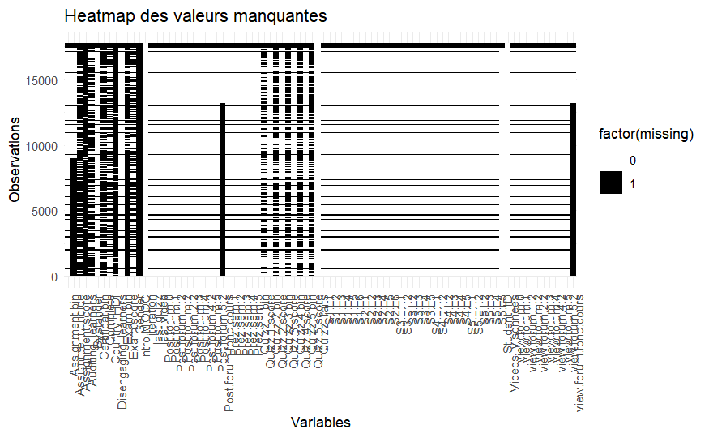

```r
#Heatmap données manquantes
# Chargez les packages nécessaires
library(ggplot2)
library(dplyr)
library(tidyr)

# Convertir les données en une matrice binaire où 1 = NA et 0 = non-NA
effec_global3_na <- effec_global3 %>%
  mutate(across(everything(), ~is.na(.)))  # transforme chaque variable en binaire (TRUE/FALSE)

# Convertir en format long pour ggplot
effec_global3_long <- effec_global3_na %>%
  pivot_longer(cols = everything(), names_to = "variable", values_to = "missing") %>%
  mutate(missing = ifelse(missing, 1, 0),  # Convertir TRUE/FALSE en 1/0
         row_id = rep(1:nrow(effec_global3), each = ncol(effec_global3)))  # Créer un identifiant unique pour chaque ligne

# Créer une heatmap avec ggplot
ggplot(effec_global3_long, aes(x = variable, y = row_id, fill = factor(missing))) +
  geom_tile() +
  scale_fill_manual(values = c("white", "black")) +  # Noir pour les valeurs manquantes, blanc pour non-manquantes
  theme_minimal() +
  labs(title = "Heatmap des valeurs manquantes",
       x = "Variables",
       y = "Observations") +
  theme(axis.text.x = element_text(angle = 90, hjust = 1))  # Rotation des noms des variables pour plus de lisibilité
```

```r
NA
NA
```

```r
#Croiser HDI et Gender

contingency_table <- table(effec_global3$Country_HDI, effec_global3$Gender)
print(contingency_table)
```

```
     un homme une femme
  B       883       147
  I       432       233
  TH     4716      2546
```

```r
# Effectuer le test du chi2

chi_result <- chisq.test(contingency_table)   # renvoie une liste
print(chi_test)
```

```
    Pearson's Chi-squared test

data:  contingency_table
X-squared = 179.05, df = 2, p-value < 2.2e-16
```

```r
# Extraire la statistique X-squared
chi_val <- chi_result$statistic
```

[output not shown]

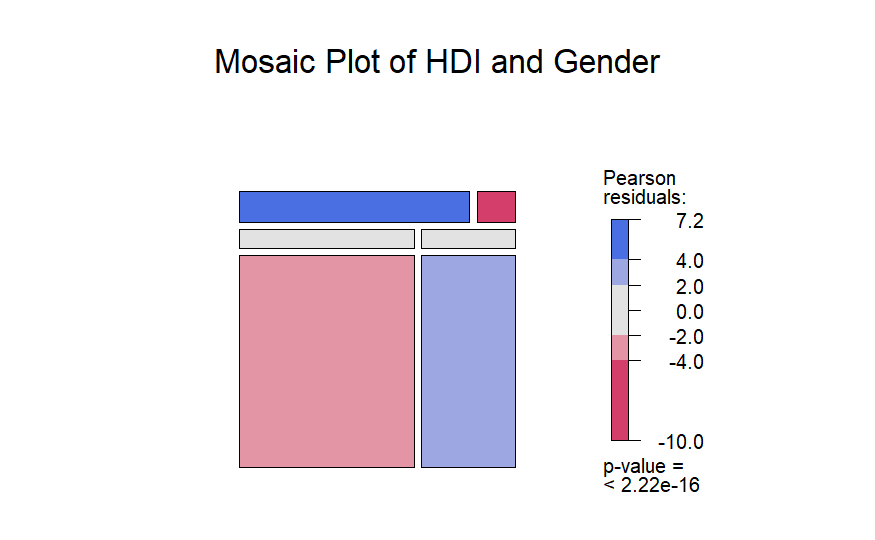

```r
# Générer un mosaic plot de la table de contingence
#install.packages("vcd")
library(vcd)

mosaic(chi_test$observed, main = "Mosaic Plot of HDI and Gender", shade = TRUE, legend = TRUE)
```

Que représentent les couleurs bleues et rouges dans un mosaic plot du test Chi2 ? Dans un mosaic plot basé sur le test Chi2, les couleurs indiquent les écarts standardisés par rapport à l’indépendance.

Couleurs bleues : Elles signalent des associations observées plus fortes que prévu sous l’hypothèse d’indépendance. Couleurs rouges : Elles signalent des associations observées moins fortes que prévu sous l’hypothèse d’indépendance. La teinte des couleurs peut également varier en fonction de la magnitude des écarts standardisés, ce qui permet de visualiser l’ampleur de la déviation.

Pourquoi n’est-il pas possible que toutes les cases soient bleues ou rouges ? Il est impossible que toutes les cases soient de la même couleur car les couleurs reflètent des écarts entre les fréquences observées et celles attendues. Si toutes les cases étaient bleues ou rouges, cela signifierait que toutes les observations s’écartent de manière cohérente dans une direction, ce qui est contradictoire avec les règles de conservation des totaux marginaux dans un tableau de contingence.

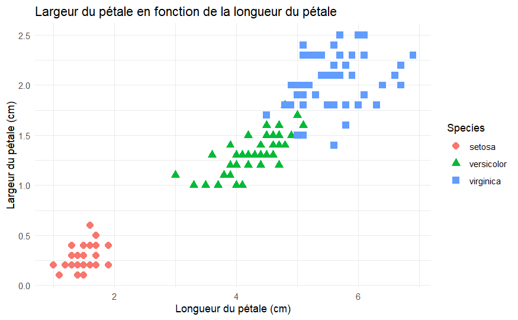

```r
#5 Mod`ele lineaire, tests non parametriques
#5.1 Sur des donnees-type

library(ggplot2)
data(iris)

ggplot(iris, aes(x = Petal.Length, y = Petal.Width, color = Species, shape = Species)) +
  geom_point(size = 3) +
  labs(title = "Largeur du pétale en fonction de la longueur du pétale",
       x = "Longueur du pétale (cm)",
       y = "Largeur du pétale (cm)") +
  theme_minimal()
```

```r
# Ajuster le modèle de régression linéaire
modele_linaire <- lm(Petal.Width ~ Petal.Length, data = iris)
summary(modele_linaire)
```

```
Call:
lm(formula = Petal.Width ~ Petal.Length, data = iris)

Residuals:
     Min       1Q   Median       3Q      Max
-0.56515 -0.12358 -0.01898  0.13288  0.64272

Coefficients:
              Estimate Std. Error t value Pr(>|t|)
(Intercept)  -0.363076   0.039762  -9.131  4.7e-16 ***
Petal.Length  0.415755   0.009582  43.387  < 2e-16 ***
---
Signif. codes:  0 ‘***’ 0.001 ‘**’ 0.01 ‘*’ 0.05 ‘.’ 0.1 ‘ ’ 1

Residual standard error: 0.2065 on 148 degrees of freedom
Multiple R-squared:  0.9271,    Adjusted R-squared:  0.9266
F-statistic:  1882 on 1 and 148 DF,  p-value: < 2.2e-16
```

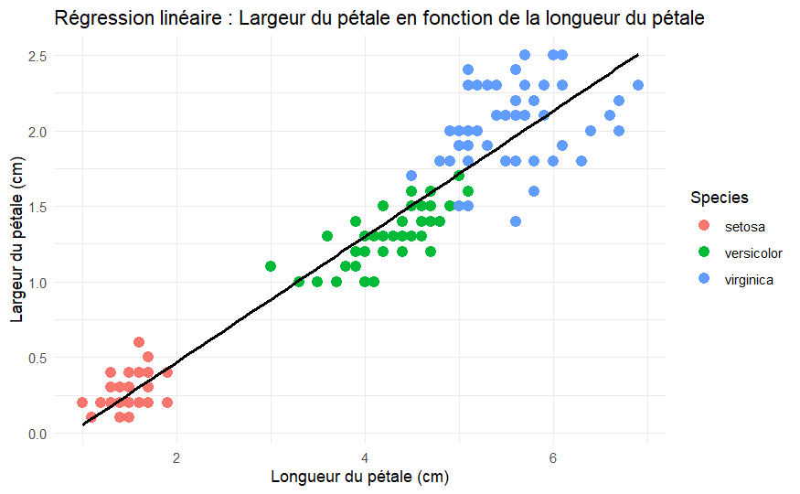

```r
ggplot(iris, aes(x = Petal.Length, y = Petal.Width)) +
  geom_point(aes(color = Species), size = 3) +  # Nuage de points
  geom_smooth(method = "lm", se = FALSE, color = "black") +  # Droite de régression
  labs(title = "Régression linéaire : Largeur du pétale en fonction de la longueur du pétale",
       x = "Longueur du pétale (cm)",
       y = "Largeur du pétale (cm)") +
  theme_minimal()
```

```r
#Pearson
correlation_pearson <- cor(iris$Petal.Length, iris$Petal.Width)
correlation_pearson
```

```
[1] 0.9628654
```

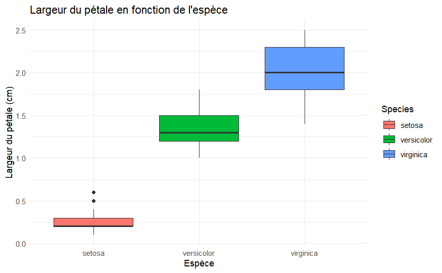

```r
#Boxplot largeur des pétales en fonction de l'espèce
ggplot(iris, aes(x = Species, y = Petal.Width, fill = Species)) +
  geom_boxplot() +  # Créer le boxplot
  labs(title = "Largeur du pétale en fonction de l'espèce",
       x = "Espèce",
       y = "Largeur du pétale (cm)") +
  theme_minimal()
```

```r
# ANOVA pour calculer la force du lien entre ces deux variables
library(ggplot2)

anova_result <- aov(Petal.Width ~ Species, data = iris)
summary(anova_result)
```

```
             Df Sum Sq Mean Sq F value Pr(>F)
Species       2  80.41   40.21     960 <2e-16 ***
Residuals   147   6.16    0.04
---
Signif. codes:  0 ‘***’ 0.001 ‘**’ 0.01 ‘*’ 0.05 ‘.’ 0.1 ‘ ’ 1
```

```r
# Table des sommes des carrés
anova_table <- summary(anova_result)
anova_table[[1]]
```

```
             Df Sum Sq Mean Sq F value    Pr(>F)
Species       2 80.413  40.207  960.01 < 2.2e-16 ***
Residuals   147  6.157   0.042
---
Signif. codes:  0 ‘***’ 0.001 ‘**’ 0.01 ‘*’ 0.05 ‘.’ 0.1 ‘ ’ 1
```

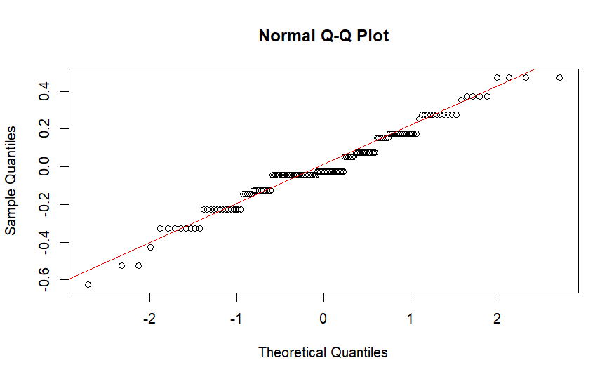

```r
#qqplot
library(ggplot2)

anova_result <- aov(Petal.Width ~ Species, data = iris)
residus <- residuals(anova_result)

# Tracer le QQ plot
qqnorm(residus)
qqline(residus, col = "red")
```

```r
#5.2 Application aux donnees des MOOC
# Appliquer le test t de Student
test_t <- t.test(Videos_visonnees ~ Gender, data = effec_global3)

# Afficher les résultats du test t
print(test_t)
```

```
    Welch Two Sample t-test

data:  Videos_visonnees by Gender
t = -3.7913, df = 5874.8, p-value = 0.0001513
alternative hypothesis: true difference in means between group un homme and group une femme is not equal to 0
95 percent confidence interval:
 -1.5165341 -0.4827664
sample estimates:
 mean in group un homme mean in group une femme
               13.50720                14.50685
```

```r
# Appliquer le test de Mann-Whitney (test non paramétrique) pour comparer les distributions des vidéos visionnées selon le genre
test_mann_whitney <- wilcox.test(Videos_visonnees ~ Gender, data = effec_global3)

# Afficher les résultats du test de Mann-Whitney
print(test_mann_whitney)
```

```
    Wilcoxon rank sum test with continuity correction

data:  Videos_visonnees by Gender
W = 8718650, p-value = 0.000388
alternative hypothesis: true location shift is not equal to 0
```

```r
# Appliquer la régression linéaire
regression_linaire <- lm(Videos_visonnees ~ Quizz_faits, data = effec_global3)
summary(regression_linaire)
```

```
Call:
lm(formula = Videos_visonnees ~ Quizz_faits, data = effec_global3)

Residuals:
     Min       1Q   Median       3Q      Max
-21.6668  -0.7128  -0.7128   2.9056  29.2872

Coefficients:
            Estimate Std. Error t value Pr(>|t|)
(Intercept)  0.71279    0.05967   11.95   <2e-16 ***
Quizz_faits  4.19080    0.02179  192.30   <2e-16 ***
---
Signif. codes:  0 ‘***’ 0.001 ‘**’ 0.01 ‘*’ 0.05 ‘.’ 0.1 ‘ ’ 1

Residual standard error: 6.228 on 17759 degrees of freedom
Multiple R-squared:  0.6756,    Adjusted R-squared:  0.6755
F-statistic: 3.698e+04 on 1 and 17759 DF,  p-value: < 2.2e-16
```

```r
# Test de corrélation de Pearson
cor_pearson <- cor.test(effec_global3$Quizz_faits, effec_global3$Videos_visonnees, method = "pearson")
print(cor_pearson)
```

```
    Pearson's product-moment correlation

data:  effec_global3$Quizz_faits and effec_global3$Videos_visonnees
t = 192.3, df = 17759, p-value < 2.2e-16
alternative hypothesis: true correlation is not equal to 0
95 percent confidence interval:
 0.8170995 0.8266436
sample estimates:
      cor
0.8219292
```

```r
# Test de corrélation de Spearman
cor_spearman <- cor.test(effec_global3$Quizz_faits, effec_global3$Videos_visonnees, method = "spearman")
print(cor_spearman)
```

```
    Spearman's rank correlation rho

data:  effec_global3$Quizz_faits and effec_global3$Videos_visonnees
S = 1.718e+11, p-value < 2.2e-16
alternative hypothesis: true rho is not equal to 0
sample estimates:
      rho
0.8160209
```

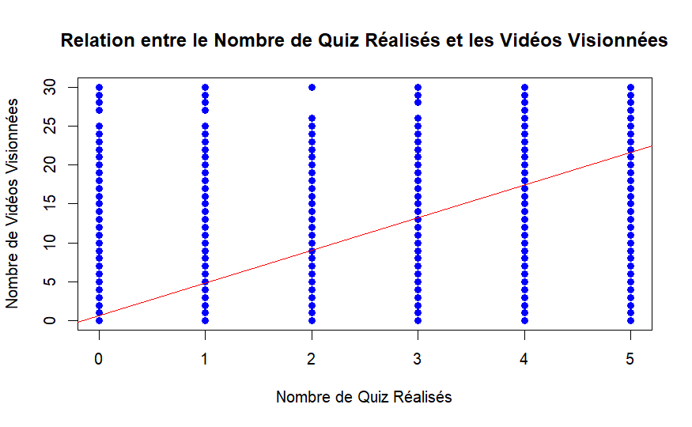

```r
# Tracer le scatterplot
plot(effec_global3$Quizz_faits, effec_global3$Videos_visonnees,
     main = "Relation entre le Nombre de Quiz Réalisés et les Vidéos Visionnées",
     xlab = "Nombre de Quiz Réalisés",
     ylab = "Nombre de Vidéos Visionnées",
     pch = 19, col = "blue")

# Ajouter la ligne de régression linéaire au scatterplot
abline(regression_linaire, col = "red")
```

```r
#ANOVA

# Modèle linéaire avec HDI et Genre comme facteurs explicatifs
mod <- lm(Videos_visonnees ~ Country_HDI + Gender, data = effec_global3)

# ANOVA pour le modèle
anova_results <- anova(mod)
summary(mod)  # Affiche un résumé du modèle linéaire
```

```
Call:
lm(formula = Videos_visonnees ~ Country_HDI + Gender, data = effec_global3)

Residuals:
    Min      1Q  Median      3Q     Max
-15.307 -10.126  -3.126  13.693  23.569

Coefficients:
                Estimate Std. Error t value Pr(>|t|)
(Intercept)       6.4314     0.3576  17.983  < 2e-16 ***
Country_HDII      4.2465     0.5704   7.444 1.07e-13 ***
Country_HDITH     8.6941     0.3839  22.646  < 2e-16 ***
Genderune femme   0.1811     0.2598   0.697    0.486
---
Signif. codes:  0 ‘***’ 0.001 ‘**’ 0.01 ‘*’ 0.05 ‘.’ 0.1 ‘ ’ 1

Residual standard error: 11.42 on 8953 degrees of freedom
  (8804 observations effacées parce que manquantes)
Multiple R-squared:  0.06101,   Adjusted R-squared:  0.06069
F-statistic: 193.9 on 3 and 8953 DF,  p-value: < 2.2e-16
```

```r
print(anova_results)  # Affiche les résultats de l'ANOVA
```

```
Analysis of Variance Table

Response: Videos_visonnees
              Df  Sum Sq Mean Sq F value Pr(>F)
Country_HDI    2   75739   37870 290.589 <2e-16 ***
Gender         1      63      63   0.486 0.4858
Residuals   8953 1166759     130
---
Signif. codes:  0 ‘***’ 0.001 ‘**’ 0.01 ‘*’ 0.05 ‘.’ 0.1 ‘ ’ 1
```

```r
#2. Interprétation des résultats

#L'ANOVA nous donne des informations sur l'effet global des variables HDI et Gender sur Videos_visonnees. Les résultats incluent :

#Sommes de carrés (SS)
#Degrés de liberté (ddl)
#Valeur F pour chaque facteur
#P-value associée
#L’ANOVA teste l’hypothèse nulle pour chaque facteur, et si la p-value est inférieure au seuil (généralement 0.05), cela indique que le facteur a un effet significatif sur le nombre de vidéos vues.

#L'HDI a un effet significatif sur le nombre de vidéos visionnées, tandis que le genre n'a pas d'effet significatif dans ce modèle.
```

```r
# ANOVA 2

# Chargement des bibliothèques nécessaires
library(tidyverse)

# Création du modèle linéaire
mod <- lm(Videos_visonnees ~ Country_HDI + Gender, data = effec_global3)

# Résumé du modèle
summary(mod)
```

```
Call:
lm(formula = Videos_visonnees ~ Country_HDI + Gender, data = effec_global3)

Residuals:
    Min      1Q  Median      3Q     Max
-15.307 -10.126  -3.126  13.693  23.569

Coefficients:
                Estimate Std. Error t value Pr(>|t|)
(Intercept)       6.4314     0.3576  17.983  < 2e-16 ***
Country_HDII      4.2465     0.5704   7.444 1.07e-13 ***
Country_HDITH     8.6941     0.3839  22.646  < 2e-16 ***
Genderune femme   0.1811     0.2598   0.697    0.486
---
Signif. codes:  0 ‘***’ 0.001 ‘**’ 0.01 ‘*’ 0.05 ‘.’ 0.1 ‘ ’ 1

Residual standard error: 11.42 on 8953 degrees of freedom
  (8804 observations effacées parce que manquantes)
Multiple R-squared:  0.06101,   Adjusted R-squared:  0.06069
F-statistic: 193.9 on 3 and 8953 DF,  p-value: < 2.2e-16
```

```r
# Analyse de la variance (ANOVA)
anova_res <- anova(mod)
print(anova_res)
```

```
Analysis of Variance Table

Response: Videos_visonnees
              Df  Sum Sq Mean Sq F value Pr(>F)
Country_HDI    2   75739   37870 290.589 <2e-16 ***
Gender         1      63      63   0.486 0.4858
Residuals   8953 1166759     130
---
Signif. codes:  0 ‘***’ 0.001 ‘**’ 0.01 ‘*’ 0.05 ‘.’ 0.1 ‘ ’ 1
```

```r
# Calcul des eta²
eta_squared <- anova_res$`Sum Sq` / sum(anova_res$`Sum Sq`)

# Créer une table d'eta²
eta_squared_table <- data.frame(
  Variable = rownames(anova_res),
  Eta_Squared = eta_squared
)

# Affichage de la table des eta²
print(eta_squared_table)
```

| Variable | Eta_Squared |
| --- | --- |
| Country_HDI | 6.095429e-02 |
| Gender | 5.096769e-05 |
| Residuals | 9.389947e-01 |

```r
NA
```

```r
# Résumé du modèle linéaire pour afficher les estimations des paramètres
summary(mod)
```

```
Call:
lm(formula = Videos_visonnees ~ Country_HDI + Gender, data = effec_global3)

Residuals:
    Min      1Q  Median      3Q     Max
-15.307 -10.126  -3.126  13.693  23.569

Coefficients:
                Estimate Std. Error t value Pr(>|t|)
(Intercept)       6.4314     0.3576  17.983  < 2e-16 ***
Country_HDII      4.2465     0.5704   7.444 1.07e-13 ***
Country_HDITH     8.6941     0.3839  22.646  < 2e-16 ***
Genderune femme   0.1811     0.2598   0.697    0.486
---
Signif. codes:  0 ‘***’ 0.001 ‘**’ 0.01 ‘*’ 0.05 ‘.’ 0.1 ‘ ’ 1

Residual standard error: 11.42 on 8953 degrees of freedom
  (8804 observations effacées parce que manquantes)
Multiple R-squared:  0.06101,   Adjusted R-squared:  0.06069
F-statistic: 193.9 on 3 and 8953 DF,  p-value: < 2.2e-16
```

```r
# Créer un tableau avec les résultats de chaque paramètre (Estimation, Erreur Std, t-value, p-value)
model_summary <- data.frame(
  Parameter = rownames(summary(mod)$coefficients),
  Estimate = summary(mod)$coefficients[, 1],
  Std_Error = summary(mod)$coefficients[, 2],
  t_value = summary(mod)$coefficients[, 3],
  p_value = summary(mod)$coefficients[, 4]
)

# Affichage du tableau des résultats
print(model_summary)
```

|  | Parameter | Estimate | Std_Error | t_value | p_value |
| --- | --- | --- | --- | --- | --- |
| (Intercept) | (Intercept) | 6.4314339 | 0.3576304 | 17.9834629 | 4.629951e-71 |
| Country_HDII | Country_HDII | 4.2464631 | 0.5704436 | 7.4441416 | 1.066015e-13 |
| Country_HDITH | Country_HDITH | 8.6941370 | 0.3839100 | 22.6462894 | 1.845498e-110 |
| Genderune femme | Genderune femme | 0.1811093 | 0.2598008 | 0.6971082 | 4.857532e-01 |

```r
NA
```

[output not shown]